# 22_06_04_experiments

```r
# l_known - length of "known" signal
# l_forecast - length of forecast
# l_window - length of window
repeats <- 10

MAX_LEN <- 150


MSE <- function(a, b) mean((a - b)^2)
normalize <- function(x) x / mean(abs(x))

exp_ <- function(base, len = MAX_LEN) normalize(exp(base * (1:len)))
cos_ <- function(period, phase = 0, len = MAX_LEN) cospi(2 * ((1:len) / period + phase))
line_ <- function(slope, b = 1 - slope * len / 2, len = MAX_LEN) normalize(slope * (1:len) + b)
exp_approx_ <- function(slope, len = MAX_LEN, base = slope, d_base = 0.0001) {
    # while (TRUE) {
        # ideal <- line_(slope)
    #     tmp <- MSE(ideal, exp_(base))
    #     d_MSE <- MSE(ideal, exp_(base + d_base)) - tmp
    #     if (abs(d_MSE) < 1e-4) break
    #     base <- base - 0.0000001 * d_MSE / d_base
    #     print("base in process")
    #     print(base)

    # }
    # print("finished")
    # print(base)
    # print(MSE(ideal, exp_(base)))
    return(exp_(base))
}
first_comp_ <- function(slope, len = MAX_LEN) {
    return(reconstruct(ssa(line_(slope, len = len)), group = list(1))$F1)
}

noises <- list(
    lapply(rep(MAX_LEN, repeats), rnorm),
    lapply(rep(MAX_LEN, repeats), rnorm))

groups <- list(list(1), list(1:2), list(1:3), list(1:4))
```

# Эксперименты с экспонентным и линейным трендом

```r
get_series1 <- get_series_mult1
get_series2 <- get_series_mult2
# get_series1 <- get_series_add1
# get_series2 <- get_series_add2

slopes <- c(0.0001, 0.0002, 0.0005, 0.001, 0.002, 0.005, 0.01)
signals <- cbind(lapply(slopes, line_), lapply(slopes, exp_approx_))
names(signals) <- c(paste("line", as.character(slopes)), paste("exp", as.character(slopes)))
```

### Линейные сигналы и их аппроксимация экспонентой

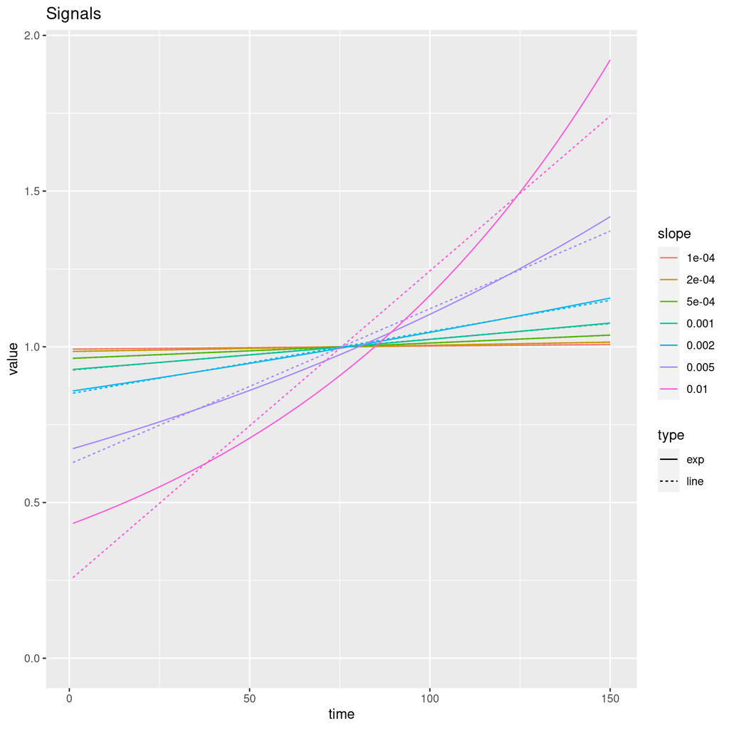

```r
ggplot(do.call(cbind.data.frame, signals) %>%
        gather() %>%
        separate(col = key, into = c("type", "slope"), sep = " ") %>%
        mutate(slope = as.factor(as.numeric(slope)))) +
    geom_line(aes(x = rep(1:MAX_LEN, length(slopes)*2),
                  y = value,
                  color = slope,
                  linetype = type)) +
    labs(title = "Signals",
         x = "time") +
    ylim(0, NA)
```

```r
# plot(signals[[1]] + (0.001 * noises[[1]][[1]]), type="l")
# plot(signals[[1]], type="l")
# plot(reconstruct(ssa(ts(signals[[1]])), group = list(1, 2)))
# plot(reconstruct(ssa(ts(signals[[7]])), group = list(1, 2)))
# plot(reconstruct(ssa(ts(signals[[1]] + (1e-5 * noises[[1]][[1]]))), group = list(1, 2)))
# plot(reconstruct(ssa(ts(signals[[7]] + (1e-2 * noises[[1]][[1]]))), group = list(1, 2)))
```

### Какая зависимость вклада второй компоненты от угла наклона сигнала?

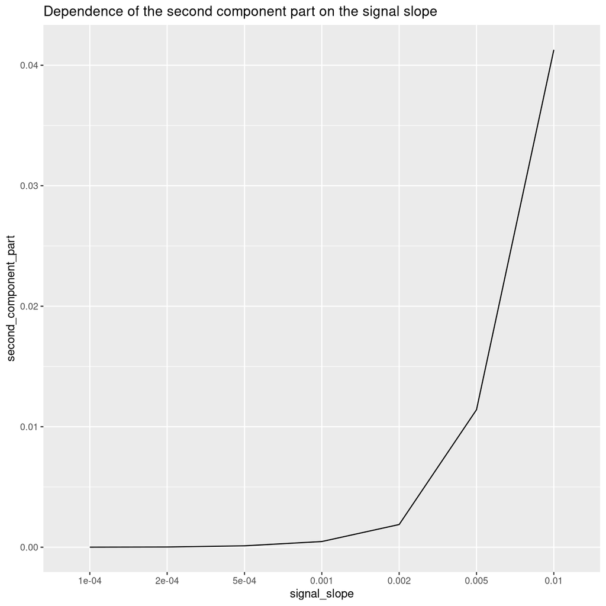

```r
line_signals <- lapply(slopes, line_)
names(line_signals) <- paste("line", as.character(slopes))


df <- expand.grid(
    signal_id = 1:length(slopes),
    crutch = list(1)
)
df$signal_slope <- factor(slopes[df$signal_id])


df$second_component_part <- apply(df, 1, function(x) {
    sigma <- ssa(line_signals[[x$signal_id]])$sigma
    return(sigma[2] / sum(sigma))
})

ggplot(df) +
    geom_path(aes(x = signal_slope,
                   y = second_component_part,
                   group = 1)) +
    labs(title = "Dependence of the second component part on the signal slope"

    )
```

похоже на экспоненту, логарифмирую

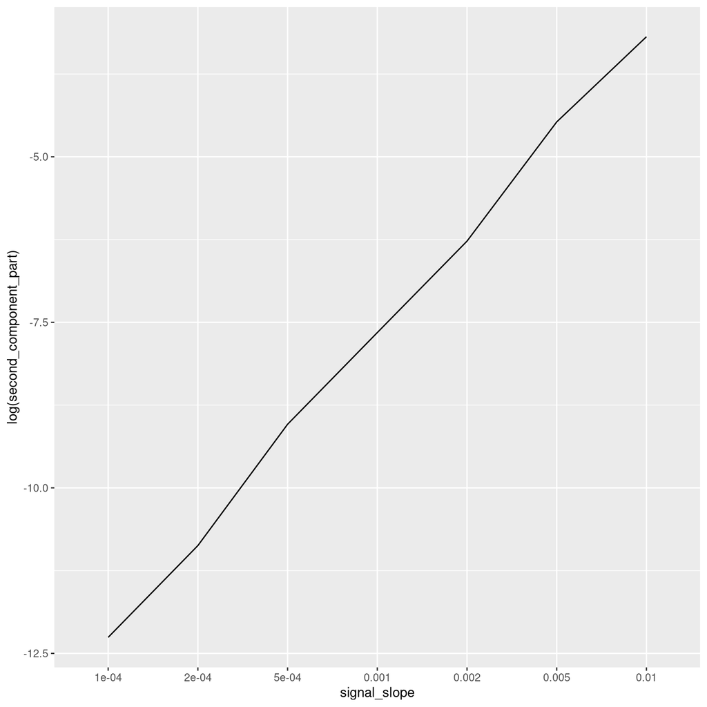

```r
ggplot(df) +
    geom_path(aes(x = signal_slope,
                   y = log(second_component_part),
                   group = 1))
```

График стал линейным, значит зависимость экспоненциальная.

Доля второй компоненты зависит от наклона сигнала экспоненциально

### При каком шуме для данного угла наклона вторая компонента теряется

план:

взять линейный сигнал

добавить шум

восстановить 2 компоненты

смотреть на ошибку

пока 2 компонента не теряется в шуме, ошибка восстановления не должна меняться, а когда 2 компонента потерялось, вместо нее берется часть шума и ошибка должна расти

повторить для каждого угла наклона

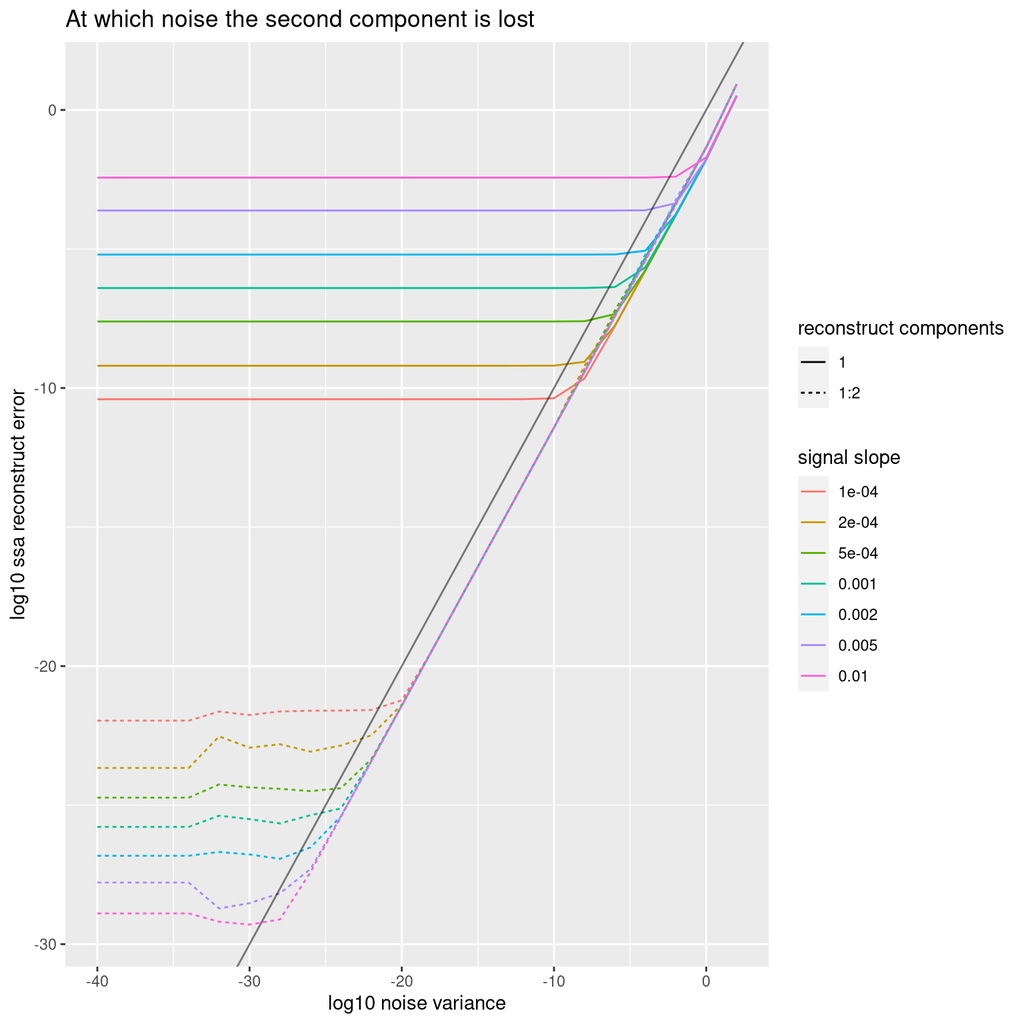

```r
line_signals <- lapply(slopes, line_)
names(line_signals) <- paste("line", as.character(slopes))

df <- expand.grid(
    signal_id = 1:length(slopes),
    noise_id = 1:repeats,
    noise_norm = 10**c(-20:1),
    group_id = c(1, 2),
    crutch = list(1)
)
df$signal_slope <- factor(slopes[df$signal_id])
df$log10_error <- apply(df, 1, function(x) {
    return(log10(MSE(line_signals[[x$signal_id]],
               reconstruct(ssa(line_signals[[x$signal_id]] + x$noise_norm * noises[[1]][[x$noise_id]]),
                           group = groups[[x$group_id]])$F1)))
})
df <- df %>%
    select(-noise_id) %>%
    group_by(across(-contains("error"))) %>%
    summarise_all(mean) %>%
    ungroup()

ggplot(df) +
    geom_line(aes(x = 2*log10(noise_norm),
                  y = log10_error,
                  color = as.factor(slopes[signal_id]),
                  linetype = as.factor(c("1", "1:2", "1:3", "1:4")[group_id]))) +
    geom_abline(intercept = 0, slope = 1, alpha = 0.5) +
    labs(title = "At which noise the second component is lost",
         x = "log10 noise variance",
         y = "log10 ssa reconstruct error",
         color = "signal slope",
         linetype = "reconstruct components")
```

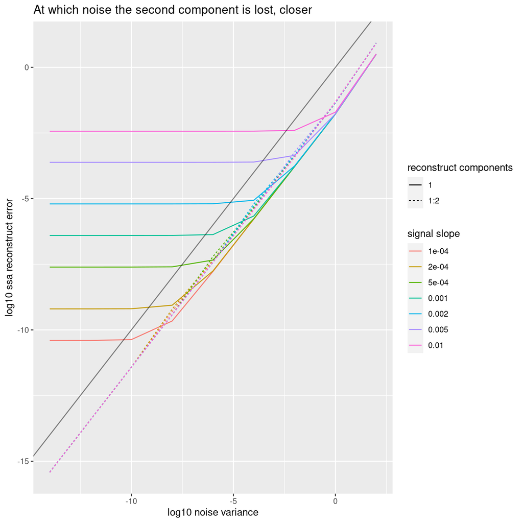

```r
ggplot(df %>% filter(noise_norm > 10**-8)) +
    geom_line(aes(x = 2*log10(noise_norm),
                  y = log10_error,
                  color = as.factor(slopes[signal_id]),
                  linetype = as.factor(c("1", "1:2", "1:3", "1:4")[group_id]))) +
    geom_abline(intercept = 0, slope = 1, alpha = 0.5) +
    labs(title = "At which noise the second component is lost, closer",
         x = "log10 noise variance",
         y = "log10 ssa reconstruct error",
         color = "signal slope",
         linetype = "reconstruct components")
```

Скачок ошибки при восстановлении двумя компонентами оказался не там где я ожидал, поэтому добавил восстановление одной компонентой и тогда скачок ошибки оказался там где я ожидал (в ручную смотрел для разных шумов когда вторая компонента теряется).

Как я понял, вторая компонента теряется при шуме, при котором восстановление двумя компонентами хуже восстановления одной. Это точки пересечения пунктирных и сплошных линий одного цвета.

Отношение логарифмов линейно и параллельно прямой x=y, значит отношение дисперсии шума к ошибке линейно.

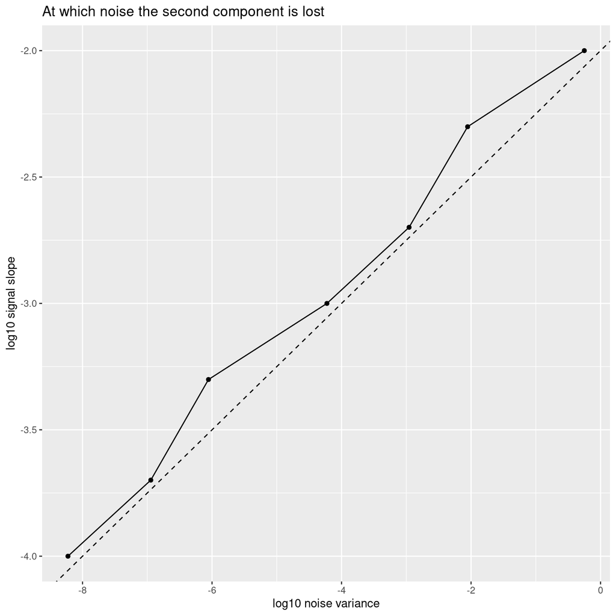

```r
approxmy <- function(x, y) {
    pos = which(x<0)[1]
    pos = c(pos - 1, pos)
    return(approx(x = x[pos], y = y[pos], xout = 0))
}


df <- df %>%
    pivot_wider(names_from = group_id, values_from = log10_error) %>%
    group_by(signal_id) %>%
    mutate(noise_border = approxmy(x = `1` - `2`,
                                 y = noise_norm)$y) %>%
    ungroup() %>%
    select(signal_id,  noise_border) %>%
    distinct()

ggplot(df,
       aes(x = 2*log10(noise_border),
           y = log10(slopes[signal_id]))) +
    geom_point() +
    geom_path(aes(group = 1)) +
    geom_abline(intercept = -2, slope = 1/4, linetype = 2) +
    labs(title = "At which noise the second component is lost",
         x = "log10 noise variance",
         y = "log10 signal slope")
```

### Линия без второй компоненты просто экспонента?

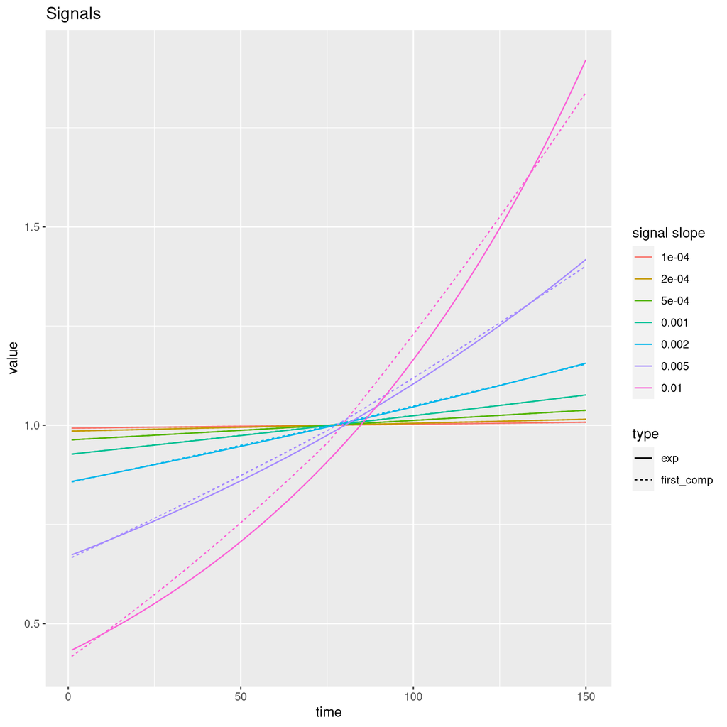

```r
slopes <- c(0.0001, 0.0002, 0.0005, 0.001, 0.002, 0.005, 0.01)
signals <- cbind(lapply(slopes, first_comp_), lapply(slopes, exp_approx_))
names(signals) <- c(paste("first_comp", as.character(slopes)), paste("exp", as.character(slopes)))

ggplot(do.call(cbind.data.frame, signals) %>%
        gather() %>%
        separate(col = key, into = c("type", "slope"), sep = " ") %>%
        mutate(slope = as.factor(as.numeric(slope)))) +
    geom_line(aes(x = rep(1:MAX_LEN, length(slopes)*2),
                  y = value,
                  color = slope,
                  linetype = type)) +
    labs(title = "Signals",
         x = "time",
         color = "signal slope")
```

Нет, линейный сигнал без второй компоненты не экспонента.